# Another Year in Reviews at rOpenSci: DRAFT

Noam Ross

1/16/2017

## Part I: Changes in the Process

Process: - Multiple handling editors - Increased use of automation - ropensci-bot - Commitment to multiple reviewers - Increased use of automated tools upstream before assigning to reviewers - goodpractice, covr, spellcheck - Checklists for editors, reviewers, and reviewees - Linkage with JOSS Policies: - Overlap requirements - Generalizability - Data packages, data extraction packages (linked to our expansion of PDF and OCR tools)

Different requirements: - CI and coverage required - Tools have gotten better, tutorials more available - Awknowledging reviewers - Little things - Function naming - First-point-of-entry documentation

## Part II: The Numbers

*Here are some initial stabs at a quantitative look at the review process, which will be part of my next “Year in Reviews” post. I’ll update with nicer styling and more text later. For now this is just an exploration to prompt further questions. Please let me know if there’s something else you want.*

We’ve grown the reviewer pool considerably. Here’s the number of reviewers by the reviews they’ve started and completed:

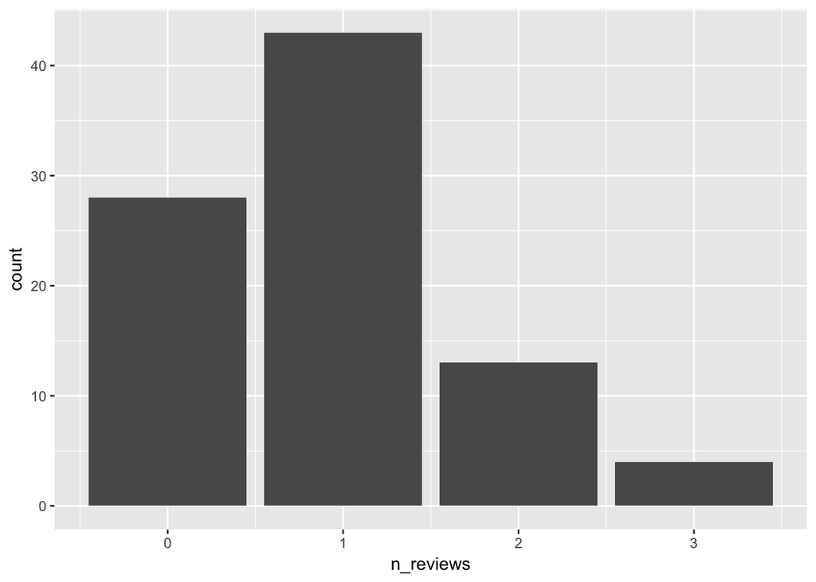

And here they are by the date of the end of their last review, with the cutoff of 6 months shown. The spike at the beginning is those with no reviews, the spike at today is those currently reviewing a package. This is conservative as it includes packages that are in “holding” mode, with no current expectation as to when authors will respons to reviews.

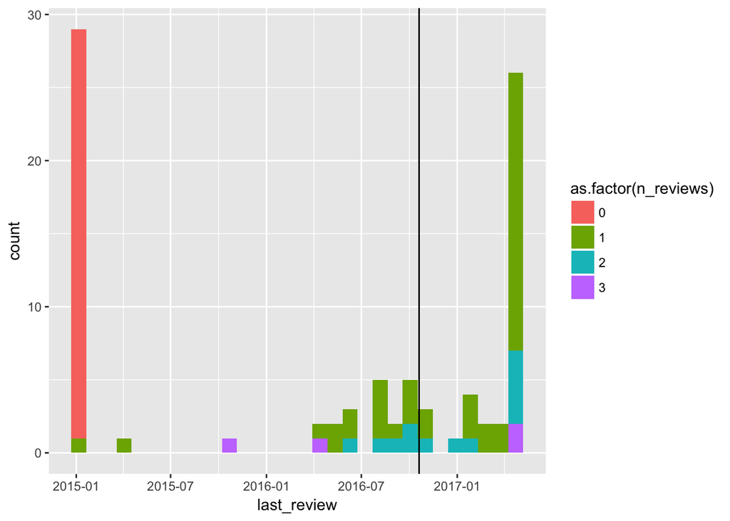

- 1 week with editor
- 1 week finding reviewers
- 3 weeks reviewing
- 2 weeks revising
- 1 week getting second reviews
- = 8 weeks = 56 days

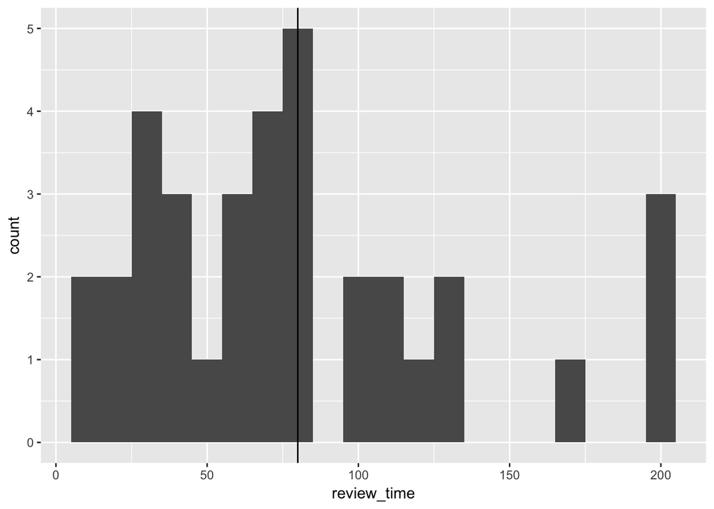

Overall, review times are holding steady or going down:

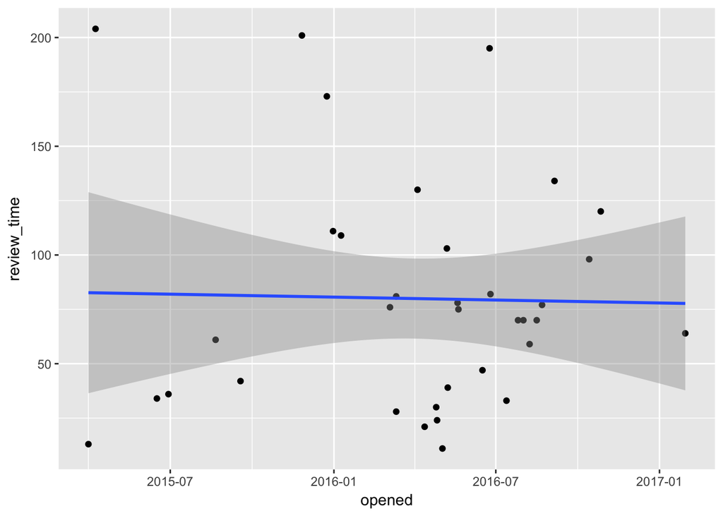

It’s possible that the surge is seasonal - it coincides with summertime for many universities. It also followed [last year’s rOpenSci unconference](http://unconf16.ropensci.org/) and the surge of publicity from last time we did a review.

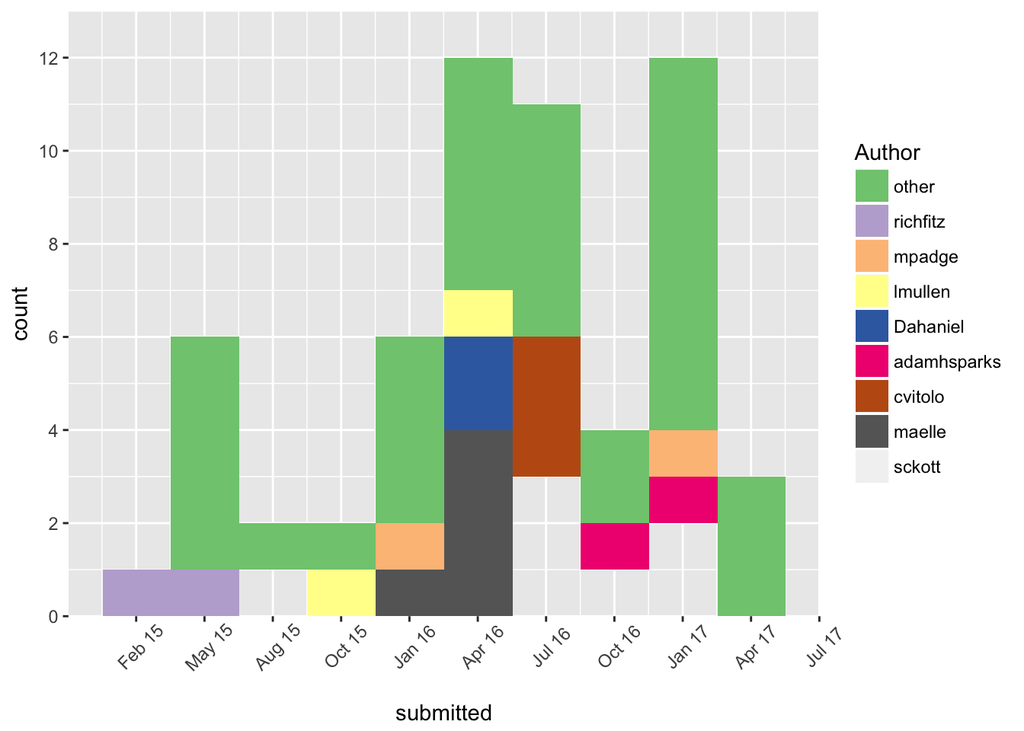

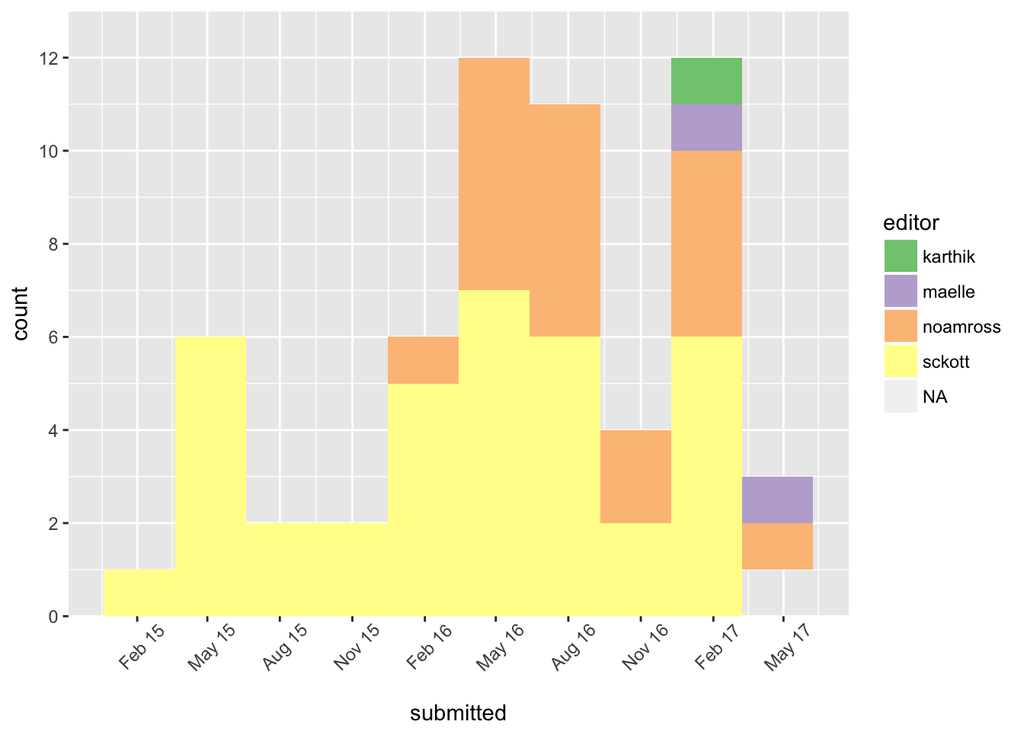

Overall, this analysis sort of confirms my priors - we’ve put a good deal of effort into improving our process and expanding our reviewer pool, but we’ve lost some momentum in increasing rates of submission and expanding our author base. This suggests we should be finding ways to do more outreach for new authors.

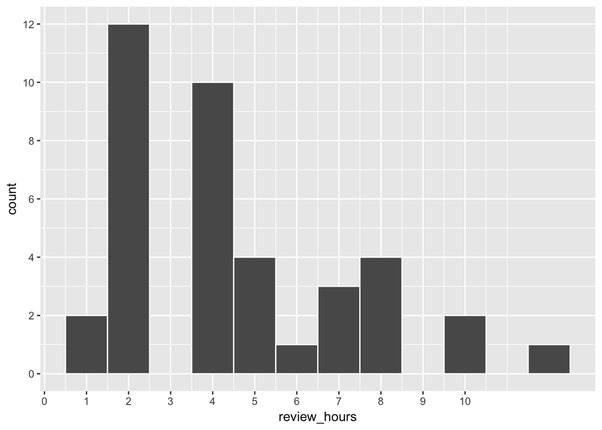

More potential analysis:

- Number of reviewers per package over time.

# Part III: What’s next

- More automation!
- Outreach to other groups. If you run or hope to run a similar group, we’d be glad to work with you to adopt some or all of our process
- Scaling down to analyses, not just packages.